# Network Analysis of Chicago Divvy Bike Trips (2019)

Network Analysis

# Mathematical Framework & Data Summary

Before processing, we define the graph parameters used throughout this report:

- Nodes: The set of stations.
- Edges: The set of trips.
- Weight: The count of trips per edge, representing the strength of the connection.
- Network Metrics: We focus on Degree (local importance) and Betweenness (global brokerage).

```r
# 1. Function Definitions (Moving logic here to keep later sections clean)
get_quarterly_metrics <- function(data, q) {
  edges <- data %>%
    filter(quarter == q) %>%
    group_by(from_station_id, to_station_id) %>%
    summarise(weight = n(), .groups = 'drop') %>%
    mutate(
      from = as.character(from_station_id),
      to = as.character(to_station_id)
    ) %>%
    select(from, to, weight) %>%
    drop_na()

  g_data <- as_tbl_graph(edges, directed = TRUE) %>%
    activate(nodes) %>%
    mutate(
      station_id = as.integer(name),
      degree = centrality_degree(mode = "all"),
      betweenness = centrality_betweenness(weights = weight),
      quarter = q
    ) %>%
    as_tibble() %>%
    left_join(stations, by = "station_id") %>%
    filter(!is.na(station_name)) %>%
    select(station_name, degree, betweenness, quarter)

  return(g_data)
}

read_divvy_quarterly <- function(f, q_label) {
  if(file.exists(f)) {
    read_csv(f, col_types = cols(from_station_id = col_integer(), to_station_id = col_integer())) %>%
      mutate(quarter = q_label)
  } else { NULL }
}

# 2. Data Ingestion
all_trips <- bind_rows(
  read_divvy_quarterly("divvy_trips_2019_Q2_clean.csv", "Q2"),
  read_divvy_quarterly("divvy_trips_2019_Q3_clean.csv", "Q3"),
  read_divvy_quarterly("divvy_trips_2019_Q4_clean.csv", "Q4")
)
stations <- read_csv("stations.csv") %>% distinct(station_id, .keep_all = TRUE)

# 3. Summary Table
summary_table <- all_trips %>%
  group_by(quarter) %>%
  summarise(Total_Trips = n(), Unique_Routes = n_distinct(paste(from_station_id, to_station_id)))

reactable(summary_table, columns = list(Total_Trips = colDef(format = colFormat(separators = TRUE))))
```

| quarter | Total_Trips | Unique_Routes |
| --- | --- | --- |
| Q2 | 1108163 | 86640 |
| Q3 | 1640718 | 101531 |
| Q4 | 704054 | 67357 |

The summary table reveals a massive surge in trips during Q3 (Summer) compared to Q2 and Q4. This indicates that while the physical Nodes (stations) remain constant, the Edges (trips) and their Weights (volume) are highly seasonal. A robust network analysis must account for this pulsing behavior of urban transit.

# Time-Series Centrality Analysis

Here, we calculate how the status of stations changes over the seasons. We compare Degree Centrality (popularity) and Betweenness Centrality (strategic location) across quarters.

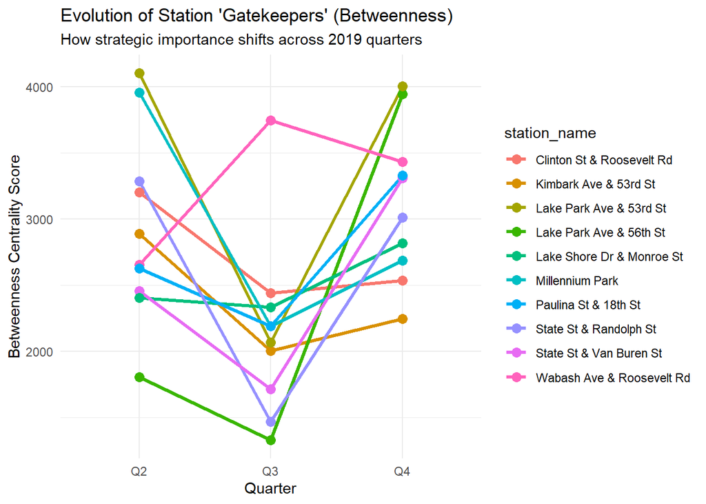

```r
# Executing quarterly analysis using the function defined above
comparison_df <- bind_rows(
  get_quarterly_metrics(all_trips, "Q2"),
  get_quarterly_metrics(all_trips, "Q3"),
  get_quarterly_metrics(all_trips, "Q4")
)

# Plotting the Top 10 Stations' Betweenness evolution
top_stations <- comparison_df %>%
  group_by(station_name) %>%
  summarise(avg_b = mean(betweenness)) %>%
  arrange(desc(avg_b)) %>%
  head(10)

ggplot(comparison_df %>% filter(station_name %in% top_stations$station_name),
       aes(x = quarter, y = betweenness, group = station_name, color = station_name)) +
  geom_line(linewidth = 1.2) +
  geom_point(size = 3) +
  theme_minimal() +
  labs(title = "Evolution of Station 'Gatekeepers' (Betweenness)",
       subtitle = "How strategic importance shifts across 2019 quarters",
       x = "Quarter",
       y = "Betweenness Centrality Score")
```

The line chart shows that Betweenness Centrality is not static. Some stations remain Hubs year-round, while others spike only in Q3.

- Betweenness Centrality: Measures the bridge role. If a station’s betweenness stays high even when total trips (Q4) drop, it is a Structural Hub—essential for the network’s geometry.
- Comparison: If a station spikes only in Q3, it is likely a Seasonal/Tourist Hub.